# Net Promoter Score Quadrant Analysis

[figure not shown]

Visualizing Customer Ratings and Expectations, on a Quadrant Plot using matplotlib in Python

Published on by [**Vimal Octavius PJ**](https://github.com/vimaloctavius)

Quadrant Plot NPS

**224 min** READ

## Visualizing Customer Ratings

### ...with Net Promoter Score and various Categories of Customer Expectations, on a Quadrant Plot

Although the data is fictitious, the approach and visualizations are pretty much from the projects I've worked on, directly. The actionable outcomes were followed through to fruition.

The NPS data contains the following fields:

- **Category** Column contains the areas of focus the customer has rated the service
- **NPS_Mean** The Average of Net Promoter Score given by various Customers, collated by **Category** so it appears against the corresponding **Category**
- **Score_Count** Count of respondents for each category
- **Percent_Contribution** The individual Contribution of that specific **Category** to the total, expressed as a percentage (.169 translates to 16.9%, .158 is 15.8% and so on...)

### Creating a Scatter Plot with quadrants

```python
import matplotlib.pyplot as plt
%matplotlib inline

import warnings
warnings.filterwarnings('ignore')
```

```python
import pandas as pd
nps_data = pd.read_csv('/content/drive/MyDrive/Datasets/NPS-Prediction - Summary.csv')
```

```python
nps_data.head()
```

|  | Category | NPS_Mean | Score_Count | Percent_Contribution |
| --- | --- | --- | --- | --- |
| 0 | OpEx | 8.500000 | 104 | 0.169657 |
| 1 | Resource Quality | 7.800000 | 97 | 0.158238 |
| 2 | Continuous Improvement | 8.000000 | 75 | 0.122349 |
| 3 | Cost Efficiency | 7.666667 | 66 | 0.107667 |
| 4 | Leadership | 7.808511 | 47 | 0.076672 |

[figure not shown]

```python
import matplotlib.pyplot as plt
from matplotlib.pyplot import figure
%matplotlib inline

def scatter_plot():
  fig1, ax1 = plt.subplots(figsize=(11,8))
  ax1.scatter(x=nps_data['NPS_Mean'],y=nps_data['Percent_Contribution'])
  ax1.set_xlabel('Average Net Promoter Score')
  ax1.set_ylabel('Category % Contribution')
  ax1.set_title('Key Customer Expectations')
  plt.plot([7.5,7.5],[0,.16], linewidth=1, color='red')
  plt.axhline(y=0.05, color='r', linestyle='-')

  for idx, row in nps_data.iterrows():
    ax1.annotate(row['Category'], (row['NPS_Mean'], row['Percent_Contribution']))

  plt.show()

with plt.style.context('dark_background'):
  scatter_plot()
```

### Takeaways from the above visualization:

Splitting the scatter plot into 4 quadrants, breaking up data points that fall before and after 7.5 Average Net Promoter Score (X axis) and, above and below a 5% Contribution of various **Categories** (Y axis) our Customers have rated the Service on.

- Top 3 aspects to continue the good work on:
1. **Operational Excellence (OpEx)**
2. **Quality of Resources Provided** and,
3. Continue to do well on **Continuous Improvement Projects**
- Top Improvement Areas could be:
1. **Providing Partnership** - work in partnership with the Customer on solutions provided, and,
2. **Be Proactive**

## Tracking Movement of Net Promoter Score

- Considering "GREEN" NPS Score or "Promoters" as those Customers who've given a rating of 9 or 10 (On a Scale of 1-10)
- "RED" as detractors, Customers who rate the service or product as 3 or below, let's draw a Quadrant like below:

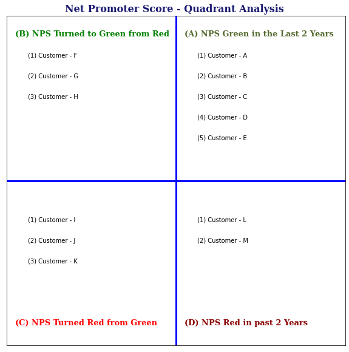

```python
font_darkgreen = {'family': 'serif',
        'color':  'darkolivegreen',
        'weight': 'bold',
        'size': 13,
        }
font_green = {'family': 'serif',
        'color':  'green',
        'weight': 'bold',
        'size': 13,
        }
font_darkred = {'family': 'serif',
        'color':  'darkred',
        'weight': 'bold',
        'size': 13,
        }
font_red = {'family': 'serif',
        'color':  'red',
        'weight': 'bold',
        'size': 13,
        }
font_blue = {'family': 'serif',
        'color':  'midnightblue',
        'weight': 'bold',
        'size': 16,
        }
plt.figure()
plt.xlim((1,9))
plt.ylim((1,9))
# Drawing Lines
plt.plot([5,5],[1,9], linewidth=3, color='blue' )
plt.plot([1,9],[5,5], linewidth=3, color='blue' )
plt.title('Net Promoter Score - Quadrant Analysis ',font_blue)

plt.rcParams["figure.figsize"] = (10,10)

#Quadrant Title
plt.text(5.2,8.5,"(A) NPS Green in the Last 2 Years",font_darkgreen)
plt.text(1.2,8.5,"(B) NPS Turned to Green from Red",font_green)
plt.text(1.2,1.5,"(C) NPS Turned Red from Green",font_red)
plt.text(5.2,1.5,"(D) NPS Red in past 2 Years",font_darkred)

#Quadrant Customer Names
plt.text(5.5,8,"(1) Customer - A")
plt.text(5.5,7.5,"(2) Customer - B")
plt.text(5.5,7,"(3) Customer - C")
plt.text(5.5,6.5,"(4) Customer - D")
plt.text(5.5,6,"(5) Customer - E")

plt.text(1.5,8,"(1) Customer - F")
plt.text(1.5,7.5,"(2) Customer - G")
plt.text(1.5,7,"(3) Customer - H")

plt.text(1.5,4,"(1) Customer - I")
plt.text(1.5,3.5,"(2) Customer - J")
plt.text(1.5,3,"(3) Customer - K")

plt.text(5.5,4,"(1) Customer - L")
plt.text(5.5,3.5,"(2) Customer - M")

#Remove X and Y ticks - Hide coordinates
plt.xticks([])
plt.yticks([])

plt.show()
```

### The above quadrant aims to track the NPS over the past 2 years. A few examples of actions that can be taken based on the quadrant are:

1. Aim to sustain and build stronger relationships with customers in Quadrant A
2. For Customers in Quadrant B, work on building stronger improvement plans, followed by execution to help move these Customers to Quadrant A
3. Customers in Quadrant C need actions to pull back the score to Green
4. Customers in Quadrant D (NPS RED in the past 2 years) need targeted break-through improvements

### The above visualization and approach may be applied to any Business, in any sector or industry, to better understand Customer Expectations and develop a plan of action...and more importantly, followed through to deliver business impact.